# GDM

Wednesday, August 05, 2015

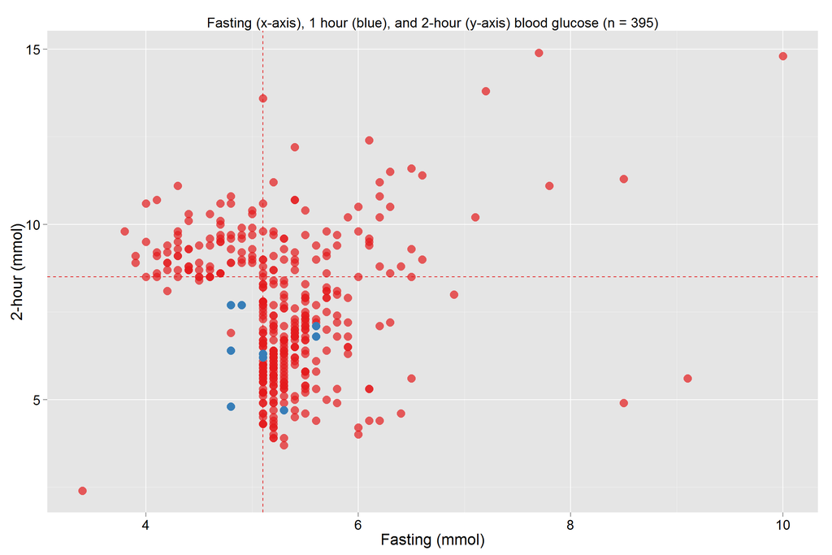

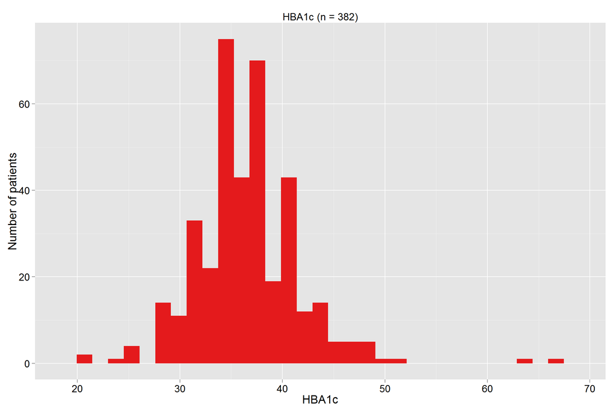

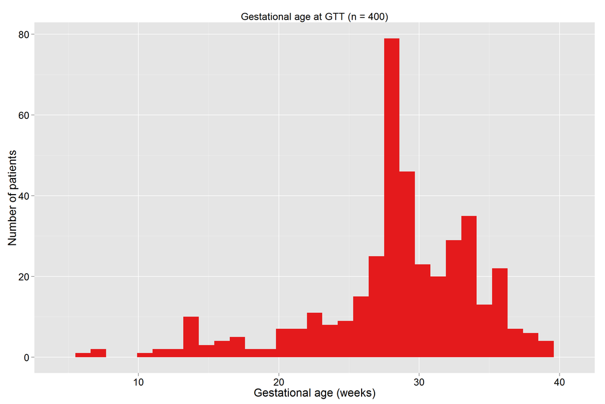

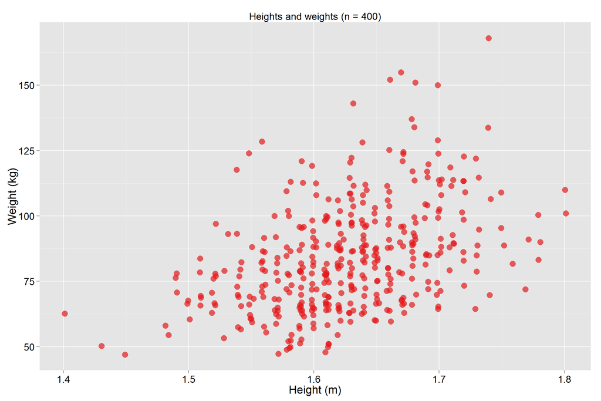

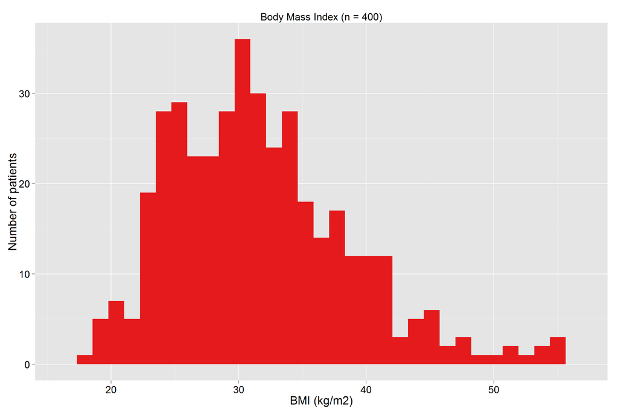

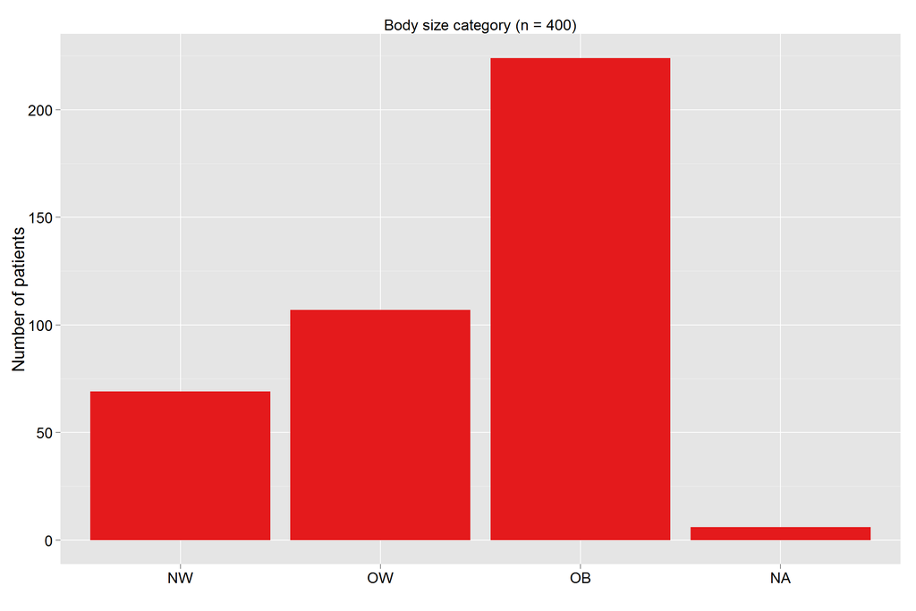

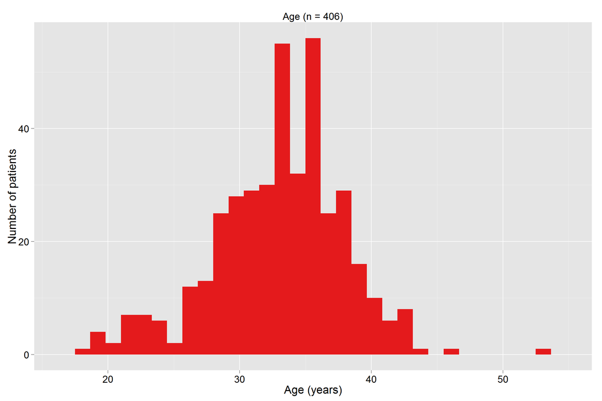

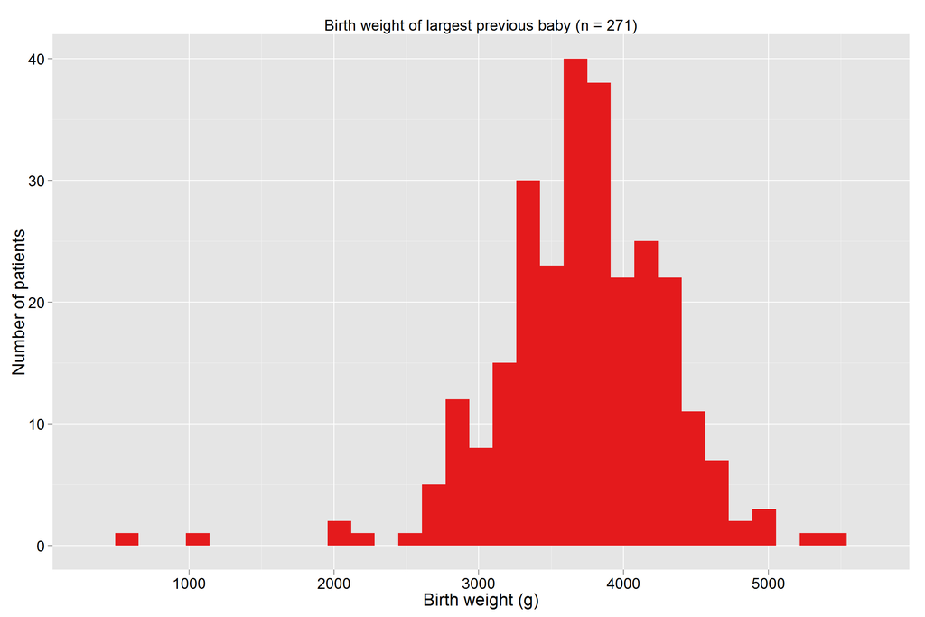

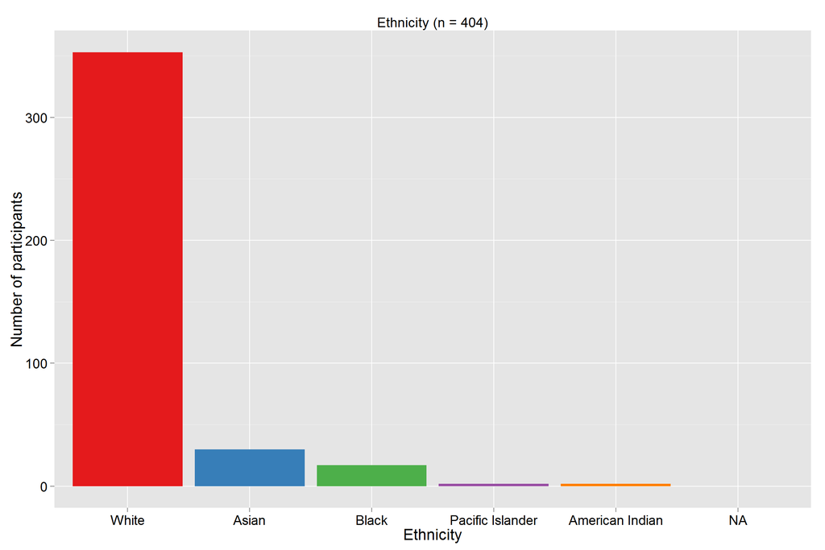

```
##
##         Irish        Polish       British      Filipino        Indian
##           282            32            13             6             6
##    Lithuanian      Nigerian   Bangladeshi     Pakistani      American
##             6             6             5             5             3
##        Slovak     Brazilian     Bulgarian       Chinese     Ghananian
##             3             2             2             2             2
##       Latvian     Portugese      Romanian       Spanish    Sri Lankan
##             2             2             2             2             2
##          Thai      Austrian     Congolise       Crotian         Czech
##             2             1             1             1             1
##        French      Georgian        German       Guinean     Hungarian
##             1             1             1             1             1
##       Italian      Jamacian      Jamaican        Libyan        Malawi
##             1             1             1             1             1
##     Malaysian     Slovakian South african      Sudanese
##             1             1             1             1
```

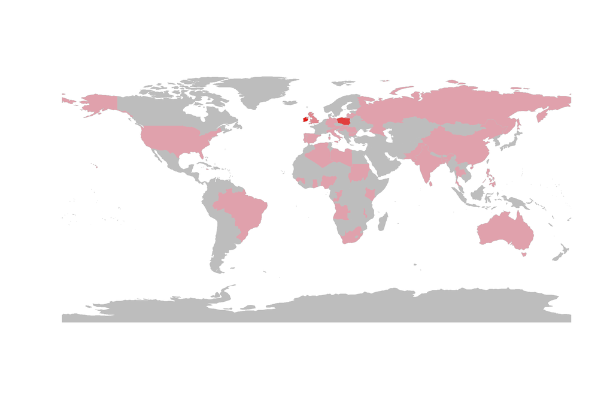

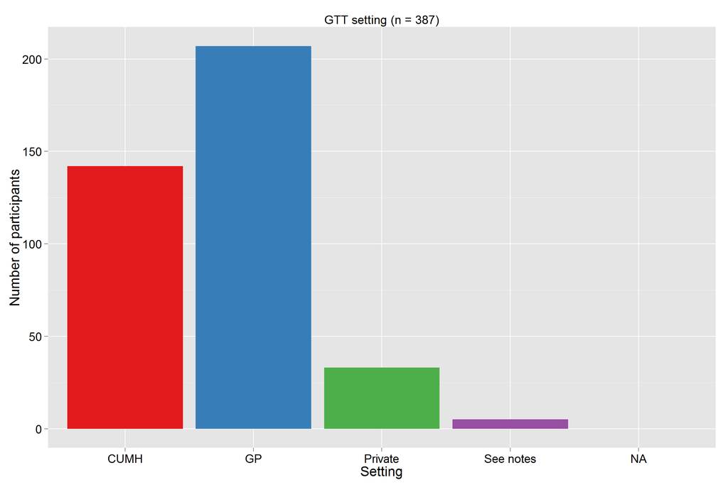

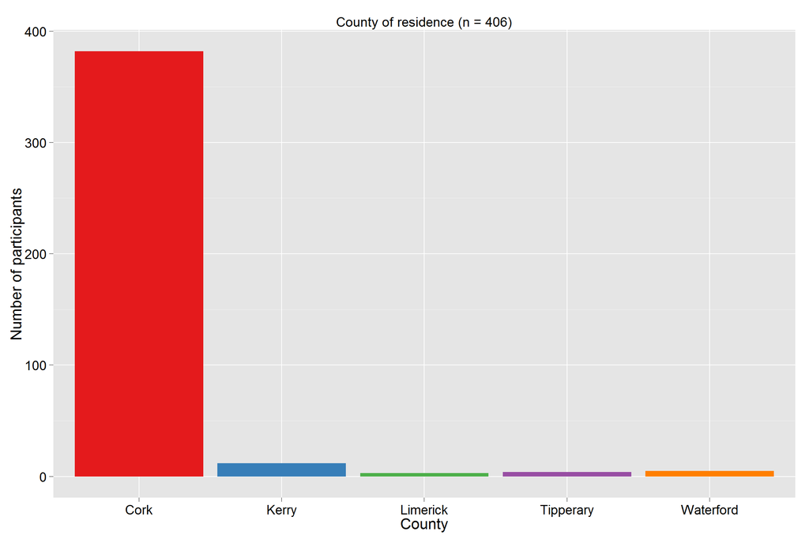

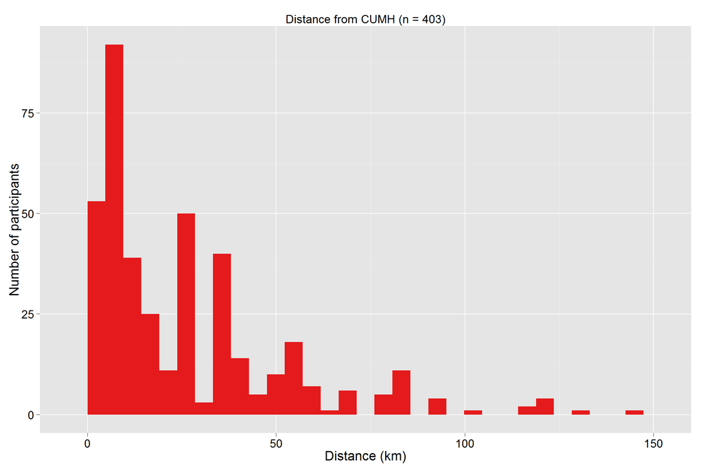

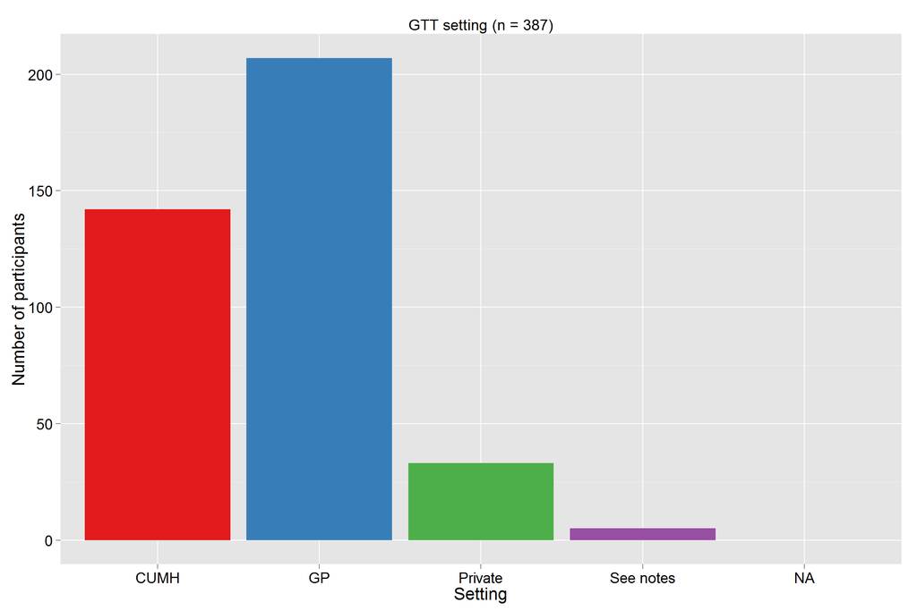

```
## Diet only
## Yes  No
## 263 141
```

```
## Referral to Endocrinology
##    None DOH/TUT   SIVUH Private
##     286      39      79       1
```

```
## Metformin
## Yes  No
##  90 312
```

```
## Basal Insulin
## Yes  No
##  97 302
```

```
## Prandial Insulin
## Yes  No
##  18 380
```

## Metformin vs Insulin

```
##                 Metformin
## Prandial Insulin Yes  No
##              Yes   4  14
##              No   84 296
```

```
##              Metformin
## Basal Insulin Yes  No
##           Yes  43  54
##           No   45 257
```

```
##                 Basal Insulin
## Prandial Insulin Yes  No
##              Yes  17   1
##              No   79 301
```

## Diet vs metformin/insulin

```
##      Metformin
## Diet  Yes  No
##   Yes   7 254
##   No   83  57
```

```
##      Prandial Insulin
## Diet  Yes  No
##   Yes   0 261
##   No   18 118
```

```
##      Basal Insulin
## Diet  Yes  No
##   Yes   0 261
##   No   97  40
```

```
## Social Class (mothers)
##      Professionals          Homemaker      Service/Sales
##                 79                 69                 67
##        Technicians   Clerical support         unemployed
##                 56                 32                 31
##           Managers         Elementary         Skilled ag
##                 15                  7                  2
##              Craft Machine opperators           Military
##                  1                  1                  0
```

```
## Social Class (partner)
##      Professionals              Craft      Service/Sales
##                 75                 53                 49
##         Elementary Machine opperators        Technicians
##                 40                 28                 27
##           Managers         unemployed         Skilled ag
##                 21                 21                 10
##   Clerical support           Military          Homemaker
##                  5                  2                  0
```

```
## Patient type
##  Public Private
##     354      51
```

```
##               Any partner
## Marital status Partner Single
##      Married       281      0
##      Single          0    106
##      Separated       0      4
##      Widow           0      0
##      Divorced        0      3
```

Folic acid

```
##                 Appropriate dose
## Took folic acid  Yes No Didn't take it
##   None             0  0             18
##   Preconception   65 50              0
##   Postconception  35 68              0
```

Multivitamin

```
## Multivitamin
## Yes  No
## 171 197
```

Smoking

```
##                   Number per day
## Smoking            None 1-5 per day 6-10 per day >10 per day <NA>
##   Never             353           0            0           0    0
##   In pregnancy        0          17           10           6    2
##   Not in pregnancy    9           0            0           0    0
##   Former              9           0            0           0    0
##   <NA>                0           0            0           0    0
```

Drinking

```
##                   Units per week
## Alcohol              0   1   2   6   9
##   None             373   0   0   1   0
##   In pregnancy       0   4   0   0   0
##   Not in pregnancy  17   0   1   0   1
```

Previous obsteric history

```
##
##              None       Miscarriage               PET               PPH
##               155               105                10                 8
## Shoulder dystocia       Ectopic/TOP              IUGR               IUD
##                 8                 7                 7                 4
##        Stillbirth              PROM       Trauma/Tear
##                 3                 2                 2
```

```
##
##       Miscarriage       Ectopic/TOP               IUD       Trauma/Tear
##                 3                 2                 1                 1
##              None        Stillbirth               PPH              IUGR
##                 0                 0                 0                 0
##               PET              PROM Shoulder dystocia
##                 0                 0                 0
```

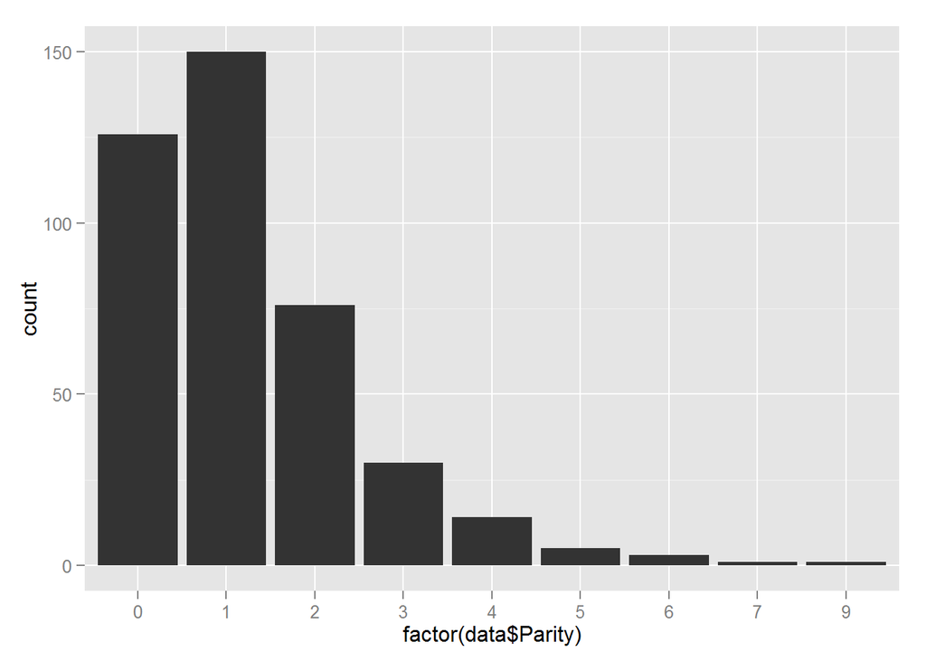

```r
    qplot(factor(data$Parity)) # Looks good
```

```r
# Gravida ###

    table(data$Gravida)
```

```
##
##   1   2   3   4   5   6   7   8   9
##  92 123  87  49  25  16   8   4   2
```

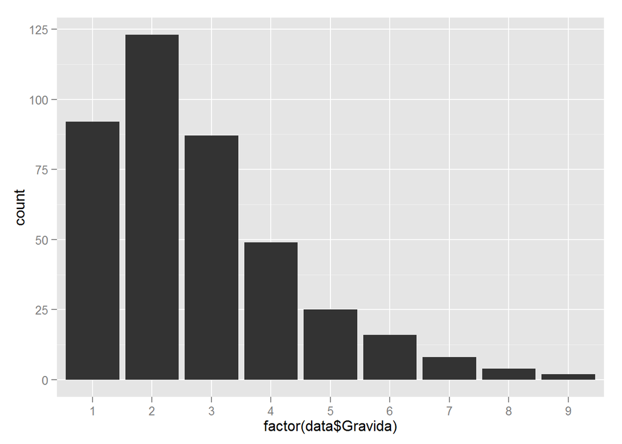

```r
    qplot(factor(data$Gravida))
```

```r
    table(data$Parity, data$Gravida)
```

```
##
##       1   2   3   4   5   6   7   8   9
##   0  92  20   8   2   3   1   0   0   0
##   1   0 102  32  10   3   3   0   0   0
##   2   0   1  46  20   6   2   0   1   0
##   3   0   0   1  17   7   3   2   0   0
##   4   0   0   0   0   5   5   4   0   0
##   5   0   0   0   0   1   2   1   1   0
##   6   0   0   0   0   0   0   1   2   0
##   7   0   0   0   0   0   0   0   0   1
##   9   0   0   0   0   0   0   0   0   1
```

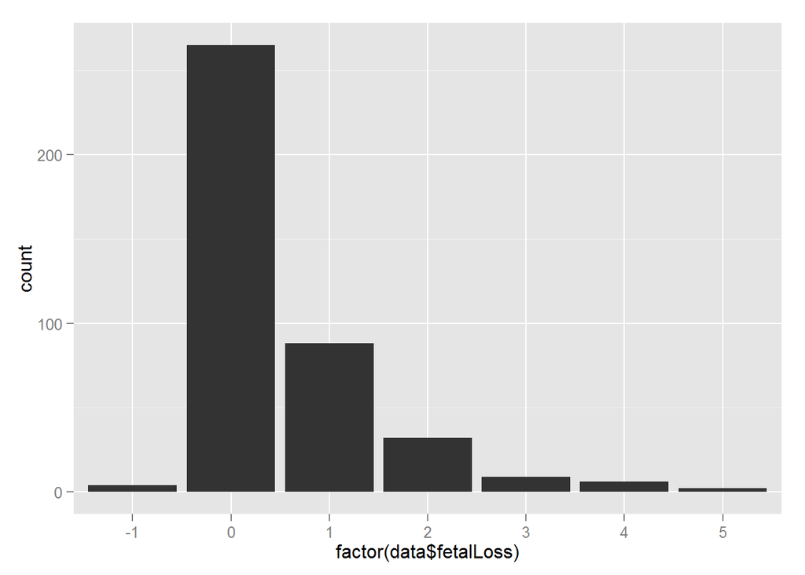

```r
# 4 observations in lower diagonal, where they should not be.

# Fetal loss ####
# Not sure if this is the best way to do this)

    data$fetalLoss <- data$Gravida - data$Parity - 1

    qplot(factor(data$fetalLoss))
```

```r
    table(factor(data$fetalLoss))
```

```
##
##  -1   0   1   2   3   4   5
##   4 265  88  32   9   6   2
```

```r
# 4 with negative values - each of these 4 have a previous history of multiple
# pregnancy (Historyofmultiplepregnancy = 1 (is that what this means?))


    table(data$Historyofmultiplepregnancy) # Not sure on coding here 0, 1, 2.
```

```
##
##   0   1   2
##  33   9 363
```

```r
# 2 people, IDs 33 and 358   - Should these be coded to reflect a prior fetal loss TODO


# Birth outcomes ##############################################################
# Gestational age ####

    table(data$Gestationatdelivery) # One with a zero TODO
```

```
##
##   0  20  30  34  35  36  37  38  39  40  41
##   1   1   2   3   8  17  40 144 146  28   1
```

```r
    table(data$Gestationalageatdeliveryday) # Why is this ever > 6? TODO
```

```
##
##   0   1   2   3   4   5   6   7   8   9  11
## 142  47  41  41  37  41  38   2   1   1   1
```

```r
    data$gestAge <- data$Gestationatdelivery + (data$Gestationalageatdeliveryday / 7)

    summary(data$gestAge)
```

```
##    Min. 1st Qu.  Median    Mean 3rd Qu.    Max.    NA's
##    0.00   38.00   38.71   38.38   39.14   41.57      15
```

```
## stat_bin: binwidth defaulted to range/30. Use 'binwidth = x' to adjust this.
```

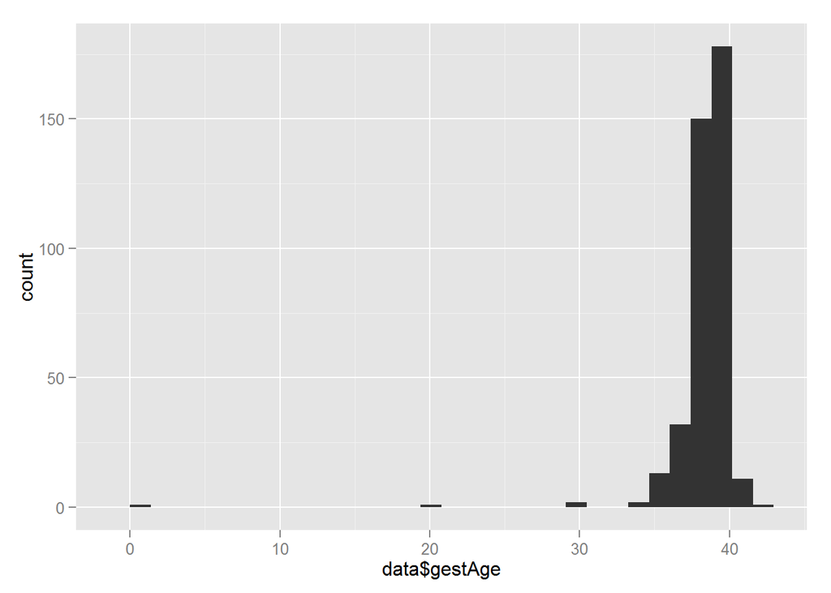

```r
    qplot(data$gestAge)
```

```r
# Normal vaginal delivery ####

  table(data$NVD)
```

```
##
##   1   2
## 231 164
```

```r
# Induction ####

  table(data$Induction)
```

```
##
##   1   2
## 195 166
```

```r
  table(data$NVD, data$Induction)
```

```
##
##       1   2
##   1 159  56
##   2  36 110
```

```r
# Operative delivery ####

  table(data$Operativedelivery)
```

```
##
##   0   1   2
## 229  96  70
```

```r
  table(data$Operativedelivery, data$NVD) # 2 classified as NVD and Operative TODO
```

```
##
##       1   2
##   0 229   0
##   1   1  95
##   2   1  69
```

```r
# Live Births ####

  table(data$LiveInfant)
```

```
##
##   0   1
##   2 395
```

## GDM screening/risk factors

Previous history of GDM. This is based on the variable PHxGDM. Women with parity 0 are labelled firstborn.

```
## Previous history of GMD
## Firstborn        No       Yes
##       125       216        65
```

Other factors for screening that we have data on are:

- Family history of diabetes in a first degree relative
- Body mass index =30kg/m2
- Maternal age = 40years
- Previous unexplained perinatal death
- Current glycosuria
- Women on long term steroids
- Previous delivery of a baby weighing =4.5kg
- Polycystic Ovary Syndrome
- Polyhydramnios and/or macrosomia in existing pregnancy
- Ethnicity associated with a high prevalence of diabetes

### Family history of diabetes in a first degree relative

```
##                     FHx Type I Diabetes
## FHx Type II Diabetes Yes  No
##                  Yes   2  82
##                  No    9 136
```

```
## Any family history of diabetes
##  No Yes
## 242 155
```

### Heights and weights (used to calculate BMI)

There were a few data entry errors that have been corrected. Here is a plot of the heights and weights.

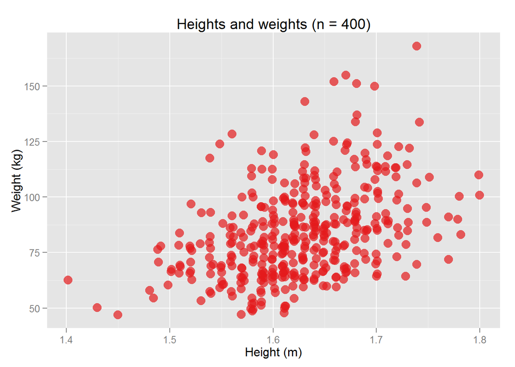

### BMI

Based on the corrected heights and weights, I calculated a new BMI variable. It does not match up perfectly with the BMI values in the dataset. Here is a plot to illustrate this.

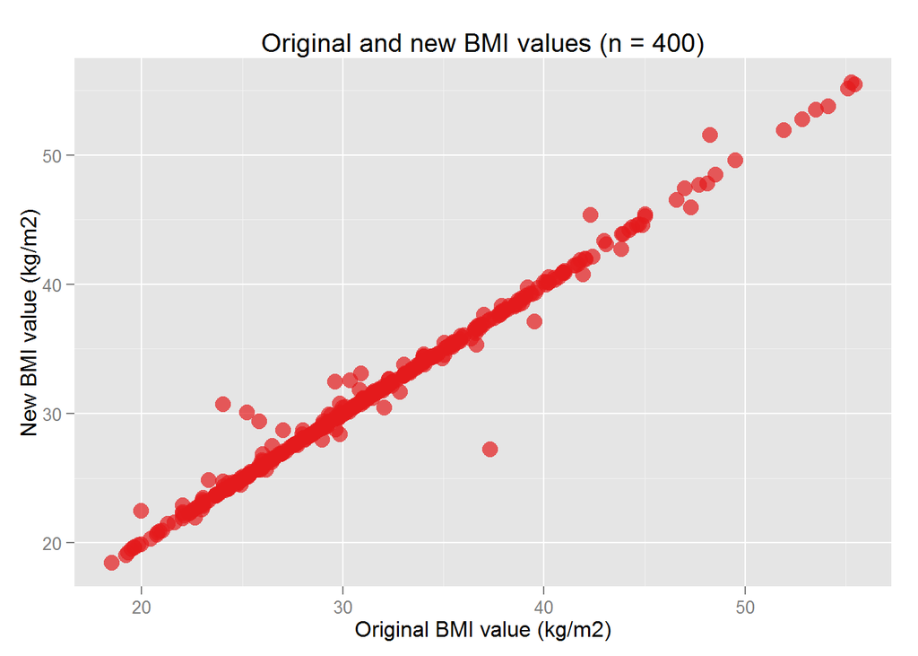

Some of the differences are large.

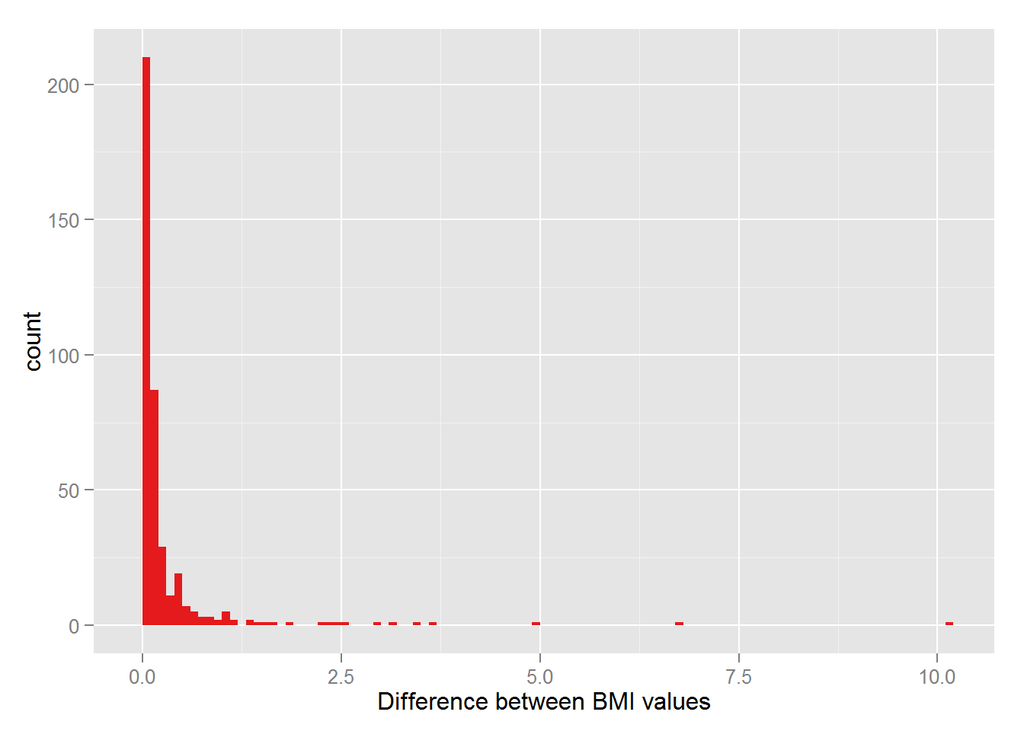

Because of these differences, I have also created a new body size classification variable. Here is how it matches up with the original version in the dataset.

```
##             Newly calculated BMI
## Original BMI  UW  NW  OW  OB
##           UW   0   7   0   0
##           NW   0  62   1   1
##           OW   0   0 105   7
##           OB   0   0   1 216
```

### Maternal age

```
##    Min. 1st Qu.  Median    Mean 3rd Qu.    Max.
##   18.00   30.00   33.00   32.97   36.00   53.00
```

```
## stat_bin: binwidth defaulted to range/30. Use 'binwidth = x' to adjust this.
```

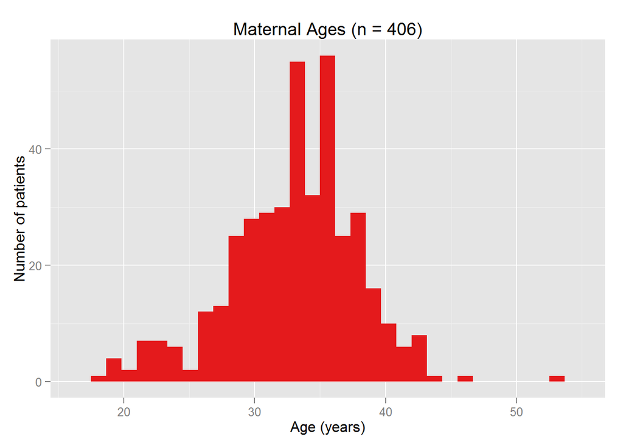

```
## Maternal age >= 40 years
##  No Yes
## 379  27
```

### Weight of the previous baby

I created a new variable which reflected a macrosomic previous baby if the variable LargeBaby indicated so, or if the variable Weightofbiggestbaby was >= 4500g. Women with a parity of zero are labelled as firstborn.

Here is a plot of the weights of the biggest previous babies.

```
## stat_bin: binwidth defaulted to range/30. Use 'binwidth = x' to adjust this.
```

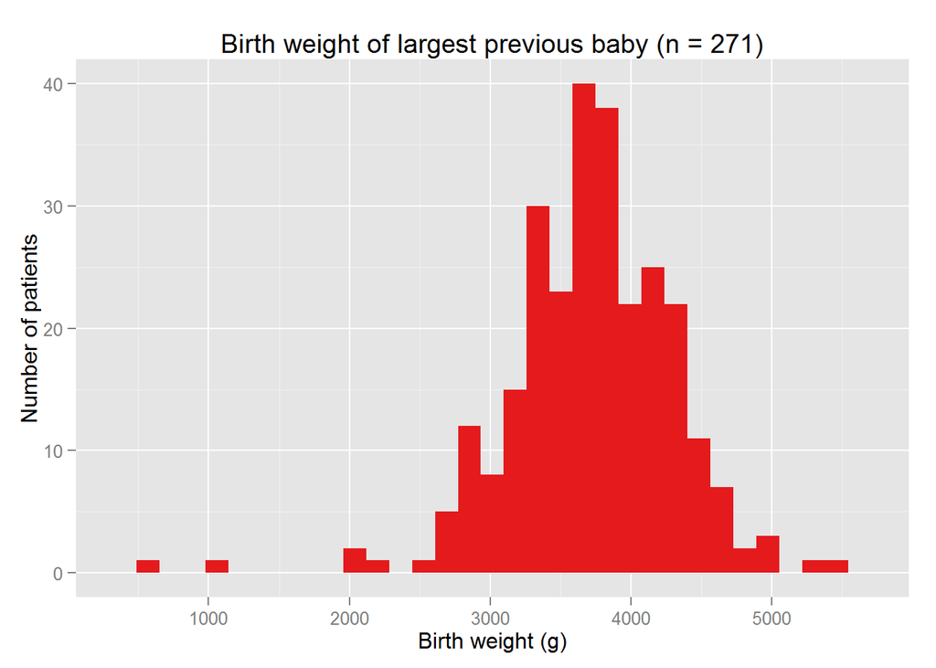

A table of LargeBaby and Parity

```
##           Parity
## Large baby   0   1   2   3   4   5   6   7   9
##        Yes   0   6   3   4   3   0   0   0   1
##        No  126 144  71  26  10   5   3   1   0
```

The new variable - not much difference.

```
## Previous macrocomic birth
## Firstborn        No       Yes
##       126       253        19
```

Here is the distribution of Weightofbiggestbaby by LargeBaby

```
## Source: local data frame [3 x 5]
##
##   as.factor(LargeBaby)     n     mean   min   max
##                 (fctr) (int)    (dbl) (dbl) (dbl)
## 1                  Yes    17 4785.938  4500  5400
## 2                   No   386 3648.133   510  4564
## 3                   NA     3      NaN    NA    NA
```

### PCOS

```
## History of PCOS
## Yes  No
##  15 391
```

### Polyhydraminos

```
## Polyhydraminos
##  No Yes
## 397   8
```

### Curent Macro

Any AC reading >= 90th centile for GA

```
## Suspected macrosomia
##  No Yes
## 215 117
```

### Ethicity

Based on black ethnicity, or country of origin being in Africa (expect South Africa), or on the list in the screening guidelines.

```
## Risky ethnicity
##  No Yes
## 367  38
```